# Advanced Bioinformatics Final 2024 assessment

Author: 23120071

Date 2024-03-22

# PART 3 - General R/Rstudio assessment (45 points)

```r
# cars is part of r, we can directly access it.
# Create a summary to understand the dataset.
summary(cars)
```

```
##      speed           dist
##  Min.   : 4.0   Min.   :  2.00
##  1st Qu.:12.0   1st Qu.: 26.00
##  Median :15.0   Median : 36.00
##  Mean   :15.4   Mean   : 42.98
##  3rd Qu.:19.0   3rd Qu.: 56.00
##  Max.   :25.0   Max.   :120.00
```

#### Task 3.1. Using the sum() function and : operator, write an expression in the code snippet to evaluate the sum of all integers between 5 and 55. (4pt)

```r
result <- sum(5:55)
print(result)
```

```
## [1] 1530
```

#### Task 3.2. Write a function called sumfun with one input parameter, called n, that calculates the sum of all integers between 5 and n. Use the function to do the calculation for n = 10, n = 20, and n = 100 and present the results. (4pt)

```r
sumfun <- function(n) {
  # Calculate the sum of integers between 5 and n
  sum <- 0
  for (i in 5:n) {
    sum <- sum + i
  }
  return(sum)
}

# Calculate the sum for n = 10, 20, and 100
result_n10 <- sumfun(10)
result_n20 <- sumfun(20)
result_n100 <- sumfun(100)

# Present the results
cat("Sum of integers between 5 and 10:", result_n10, "\n")
```

```
## Sum of integers between 5 and 10: 45
```

```r
cat("Sum of integers between 5 and 20:", result_n20, "\n")
```

```
## Sum of integers between 5 and 20: 200
```

```r
cat("Sum of integers between 5 and 100:", result_n100, "\n")
```

```
## Sum of integers between 5 and 100: 5040
```

#### Task 3.3. The famous Fibonacci series is calculated as the sum of the two preceding members of the sequence, where the first two steps in the sequence are 1, 1. Write an R script using a for loop to calculate and print out the first 12 entries of the Fibonacci series. (4pt)

```r
# Initialize the first two Fibonacci numbers
fibonacci <- c(1, 1)

# Loop to calculate the next 10 Fibonacci numbers
for (i in 3:12) {
  next_fib <- fibonacci[i - 1] + fibonacci[i - 2]
  fibonacci <- c(fibonacci, next_fib)
}

# Print out the Fibonacci series
cat("First 12 entries of the Fibonacci series:\n")
```

```
## First 12 entries of the Fibonacci series:
```

```r
for (i in 1:12) {
  cat(fibonacci[i], " ")
}
```

```
## 1  1  2  3  5  8  13  21  34  55  89  144
```

```r
cat("\n")
```

#### Task 3.4. With the mtcars dataset bundled with R, use ggplot to generate a box of miles per gallon (in the variable mpg) as a function of the number of gears (in the variable gear). Use the fill aesthetic to colour bars by number of gears. (4pt)

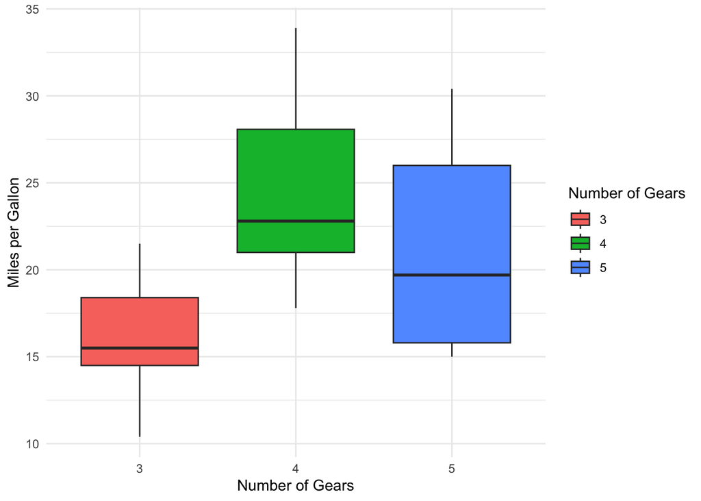

```r
# Load the ggplot2 library
library(ggplot2)

# Load the mtcars dataset
data(mtcars)

# Create the boxplot using ggplot
ggplot(mtcars, aes(x = as.factor(gear), y = mpg, fill = as.factor(gear))) +
  geom_boxplot() +
  labs(x = "Number of Gears", y = "Miles per Gallon") +
  scale_fill_discrete(name = "Number of Gears") +
  theme_minimal()
```

#### Task 3.5. Using the cars dataset and the function lm, fit a linear relationship between speed and breaking distance in the variable distance. What are the fitted slope and intercept of the line, and their standard errors? What are the units used for the variables in the dataset? (4pt)

```r
# Load the cars dataset
data(cars)

# Fit a linear model
model <- lm(dist ~ speed, data = cars)

# Retrieve slope, intercept, and their standard errors
slope <- coef(model)[2]
intercept <- coef(model)[1]
slope_se <- summary(model)$coefficients[2, 2]
intercept_se <- summary(model)$coefficients[1, 2]

# Print the results
cat("Fitted slope:", slope, "\n")
```

```
## Fitted slope: 3.932409
```

```r
cat("Slope standard error:", slope_se, "\n")
```

```
## Slope standard error: 0.4155128
```

```r
cat("Fitted intercept:", intercept, "\n")
```

```
## Fitted intercept: -17.57909
```

```r
cat("Intercept standard error:", intercept_se, "\n")
```

```
## Intercept standard error: 6.75844
```

```r
cat("Units for speed: miles per hour (mph)\n")
```

```
## Units for speed: miles per hour (mph)
```

```r
cat("Units for distance: feet (ft)\n")
```

```
## Units for distance: feet (ft)
```

#### Task 3.6. Use ggplot to plot the data points from Task 6 and the linear fit. (4pt)

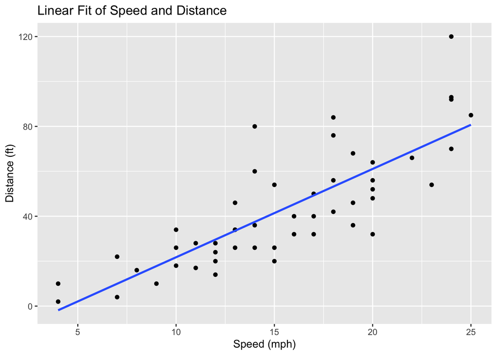

```r
# Load the ggplot2 library
library(ggplot2)

# Fit a linear model
model <- lm(dist ~ speed, data = cars)

# Create a scatter plot with ggplot
p <- ggplot(cars, aes(x = speed, y = dist)) +
  geom_point() +  # Add points for the data
  geom_smooth(method = "lm", se = FALSE) +  # Add a linear fit line
  labs(x = "Speed (mph)", y = "Distance (ft)", title = "Linear Fit of Speed and Distance")

# Print the plot
print(p)
```

#### Task 3.7. Again using the cars dataset, now use linear regression (lm) to estimate the average reaction time for the driver to start breaking (in seconds). To simplify matters you may assume that once breaking commences, breaking distance is proportional to the square of the speed. Explain the steps in your analysis. Do you get reasonable results? Finally, use ggplot to plot the data points and the fitted relationship. (9pt)

```r
# Add the square of the speed to the dataset
cars <- mutate(cars, speed_squared = speed^2)

# Fit the linear model
model <- lm(dist ~ speed_squared, data = cars)

# Summarize the model to get coefficients and standard errors
model_summary <- summary(model)

# The ntercept is the distance covered during the driver's reaction time,
# we calculate the average reaction time by dividing it by the average speed..
average_speed <- mean(cars$speed)
intercept <- model_summary$coefficients["(Intercept)", "Estimate"]
intercept_se <- model_summary$coefficients["(Intercept)", "Std. Error"]

# Convert intercept to time by dividing by the average speed
# Convert speed from mph to fps (feet per second) by multiplying by 1.467 (since 1 mph = 1.467 fps)
estimated_reaction_time <- intercept / (average_speed * 1.467)
standard_error_reaction_time <- intercept_se / (average_speed * 1.467)

# Output the estimated reaction time and its standard error
print(paste("Estimated average reaction time (seconds):", estimated_reaction_time))
```

```
## [1] "Estimated average reaction time (seconds): 0.39217984174362"
```

```r
print(paste("Standard error of estimated average reaction time (seconds):", standard_error_reaction_time))
```

```
## [1] "Standard error of estimated average reaction time (seconds): 0.180876642762238"
```

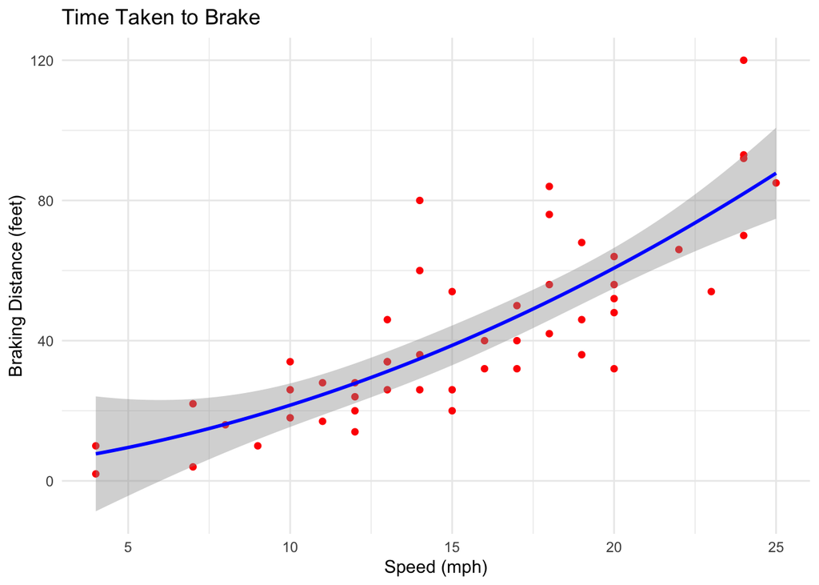

```r
# Plot the data points and the fitted relationship
library(ggplot2)

# Once we have a fitted model, we use it to plot
ggplot(cars, aes(x = speed, y = dist)) +
  geom_point(color = "red") +  # This plots the data points in red
  geom_smooth(method = "lm", formula = y ~ poly(x, 2), se = TRUE, color = "blue") +  # This adds a fitted quadratic line with a confidence interval
  labs(x = "Speed (mph)", y = "Braking Distance (feet)",
       title = "Time Taken to Brake") +
  theme_minimal()  # This gives a minimalistic theme similar to the provided graph
```

# PART 4 - RNA-seq assessment (8 pts)

#### TASK 3.8. Read in count data and sample description. (1pts)

```r
# Set the file paths
count_data_path <- "/Users/estebantato/Desktop/LMS_RNAseq_short-master-2023-final/course/exercises/data/exercise1_counts.csv"
sample_description_path <- "/Users/estebantato/Desktop/LMS_RNAseq_short-master-2023-final/course/exercises/data/exercise1_sample_description.info"

# Read in count data
count_data <- read.csv(count_data_path, row.names = 1, check.names = FALSE)

# Read in sample description
sample_description <- read.csv(sample_description_path, header = TRUE)

# View the first few lines of the data
head(count_data)
```

```
##           control_FFa1.bam control_FFa2.bam control_FFa3.bam mutant_KOa1.bam
## 497097                  16               16                0              21
## 100503874               20                0                0              64
## 100038431                0                0                2               0
## 19888                   11                0               10             113
## 20671                   14               16                0              40
## 27395                  465              193              596             436
##           mutant_KOa2.bam mutant_KOa3.bam mutant_KOb1.bam mutant_KOb2.bam
## 497097                 16              27              20               0
## 100503874               0               4               5               0
## 100038431               0               8               0               0
## 19888                   0              26              14               6
## 20671                   8              33              33              12
## 27395                 686             572            1378            1901
##           mutant_KOb3.bam
## 497097                  2
## 100503874               2
## 100038431               0
## 19888                  16
## 20671                  24
## 27395                1553
```

```r
head(sample_description)
```

```
##     filename.sample.condition.batch
## 1    control_FFa1.bam\tFFa1\tFFa\ta
## 2    control_FFa2.bam\tFFa2\tFFa\tb
## 3    control_FFa3.bam\tFFa3\tFFa\tc
## 4 TMC_mutant_KOa1.bam\tKOa1\tKOa\ta
## 5 TMC_mutant_KOa2.bam\tKOa2\tKOa\tb
## 6 TMC_mutant_KOa3.bam\tKOa3\tKOa\tc
```

#### TASK 3.9 Create col_data and check dimensions. (1 pts)

```r
# Check dimensions
col_data <- sample_description
dim_count_data <- dim(count_data)
dim_col_data <- dim(col_data)

# Print dimensions
cat("Dimensions of count_data: ", dim_count_data[1], "rows by", dim_count_data[2], "columns\n")
```

```
## Dimensions of count_data:  26301 rows by 9 columns
```

```r
cat("Dimensions of col_data: ", dim_col_data[1], "rows by", dim_col_data[2], "columns\n")
```

```
## Dimensions of col_data:  9 rows by 1 columns
```

```r
# Ensure the number of columns in count_data matches the number of rows in col_data
if (dim_count_data[2] == dim_col_data[1]) {
  cat("The dimensions align correctly.\n")
} else {
  cat("Warning: The dimensions do not align! Check your data.\n")
}
```

```
## The dimensions align correctly.
```

#### TASK 3.10 Construct DESeqDataSet object using count data and sample description. (1 pts)

```r
# Load DESeq2
library(DESeq2)

# Extract 'condition' from the 'filename.sample.condition.batch' column
col_data$condition <- sapply(strsplit(col_data$filename.sample.condition.batch, "_"), function(x) x[1])

# Convert 'condition' to a factor and set the reference level, if there is one
col_data$condition <- factor(col_data$condition)

# Now, check the new 'condition' column to ensure it looks correct
head(col_data$condition)
```

```
## [1] control control control TMC     TMC     TMC
## Levels: control TMC
```

```r
# Now create the DESeqDataSet
dds <- DESeqDataSetFromMatrix(countData = count_data,
                              colData = col_data,
                              design = ~ condition)

# Check the constructed DESeqDataSet object
dds
```

```
## class: DESeqDataSet
## dim: 26301 9
## metadata(1): version
## assays(1): counts
## rownames(26301): 497097 100503874 ... 100040384 100040400
## rowData names(0):
## colnames(9): control_FFa1.bam control_FFa2.bam ... mutant_KOb2.bam
##   mutant_KOb3.bam
## colData names(2): filename.sample.condition.batch condition
```

#### TASK 3.11. Perform rlog and VST transformation on the data.

```r
# Perform the rlog transformation
# 'blind=TRUE' for exploratory purposes
rlog_dds <- rlog(dds, blind=TRUE)

# Perform the Variance Stabilizing Transformation (VST)
# Similarly, 'blind=TRUE' for exploratory purposes
vst_dds <- vst(dds, blind=TRUE)

# At this point, rlog_dds and vst_dds contain the transformed data
```

#### TASK 3.12. Draw a heatmap of count matrix based on the top 40 highly expressed genes using rlog and VST data.

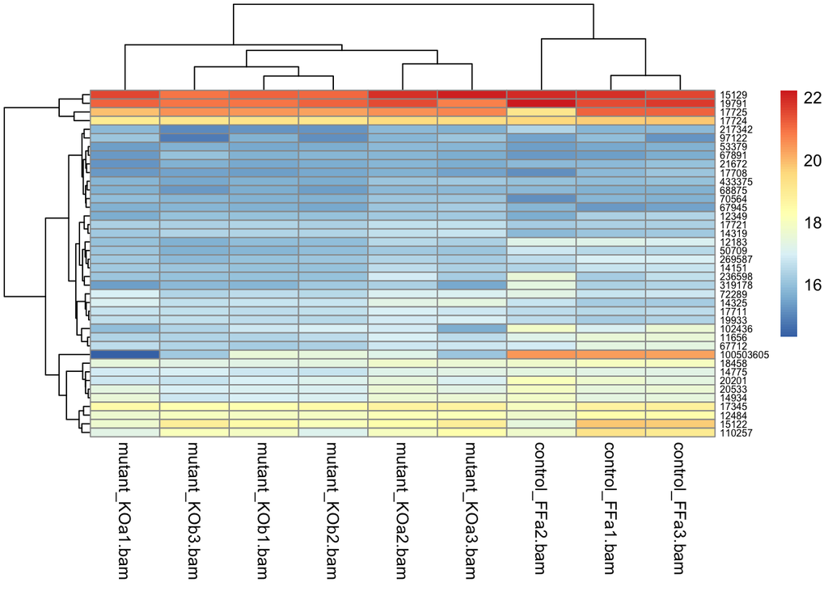

```r
# Make sure the DESeq2 object has been processed through rlog or VST
# If not, run the transformations
rlog_dds <- rlog(dds, blind = TRUE)
vst_dds <- vst(dds, blind = TRUE)

# For the heatmap, choose which transformation to use: rlog or VST.
# Transformation using rlog.
transformed_counts <- assay(rlog_dds)

# Identify the top 40 genes with the highest mean expression
top_genes <- head(order(rowMeans(transformed_counts), decreasing = TRUE), 40)

# Extract the subset of the rlog-transformed data for the top genes
top_genes_rlog_data <- transformed_counts[top_genes,]

# Draw the heatmap using pheatmap
  pheatmap(top_genes_rlog_data,
         cluster_rows = TRUE,
         cluster_cols = TRUE,
         show_rownames = TRUE,
         show_colnames = TRUE,
         fontsize_row = 6,
         fontsize_col = 10)
```

#### TASK 3.13. Generate a SDM to see the clustering of count data. (1 pts)

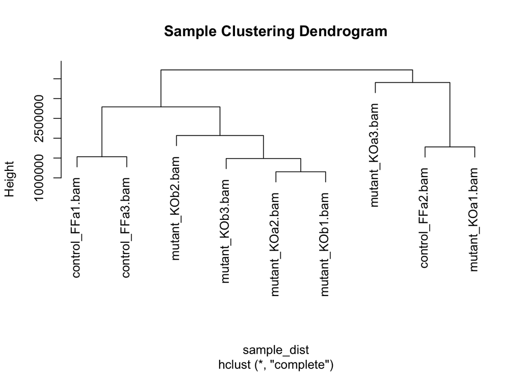

```r
# Calculate sample distance matrix
sample_dist <- dist(t(count_data))

# Perform hierarchical clustering
sample_hclust <- hclust(sample_dist, method = "complete")

# Plot the dendrogram
plot(sample_hclust, main = "Sample Clustering Dendrogram")
```

#### TASK 3.14. Perform the Principal Component Analysis using rlog method and find out the % significance values of first two principal components. (1 pts)

```r
# Perform PCA using rlog-transformed data
ls()
```

[output not shown]

```r
pca_rlog <- prcomp(t(assay(rlog_dds)))

# Extract the proportion of variance explained by each principal component
variance_explained <- pca_rlog$sdev^2 / sum(pca_rlog$sdev^2)

# Calculate the percentage significance values of the first two principal components
percentage_significance <- variance_explained[1:2] * 100

# Print the percentage significance values
percentage_significance
```

```
## [1] 34.98241 31.37770
```

#### TASK 3.15. Repeat the PCA, this time using VST method and compare the plots with the ones obtained using rlog method. (1 pts)

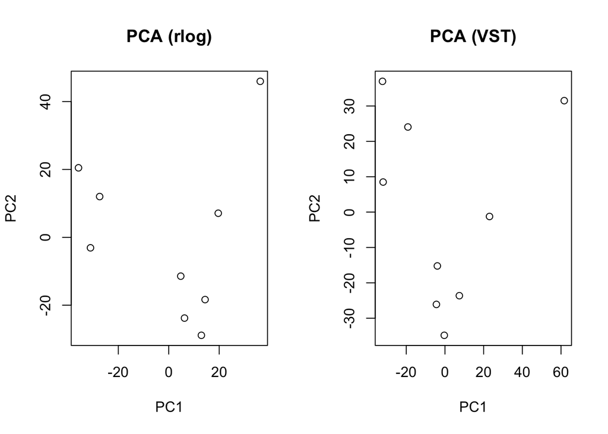

```r
# Perform PCA using VST-transformed data
pca_vst <- prcomp(t(assay(vst_dds)))

# Extract the proportion of variance explained by each principal component for VST-transformed data
variance_explained_vst <- pca_vst$sdev^2 / sum(pca_vst$sdev^2)

# Calculate the percentage significance values of the first two principal components for VST-transformed data
percentage_significance_vst <- variance_explained_vst[1:2] * 100

# Plot the PCA for comparison with rlog-transformed data
par(mfrow = c(1, 2))  # Set up a 1x2 plotting grid
plot(pca_rlog$x[,1], pca_rlog$x[,2], xlab = "PC1", ylab = "PC2", main = "PCA (rlog)")
plot(pca_vst$x[,1], pca_vst$x[,2], xlab = "PC1", ylab = "PC2", main = "PCA (VST)")
```

# PART 5 -ChIP-seq assessment (4 pts)

#### Task 3.16. Read in the two Myc Mel peakset replicates and create the common peakset as we did for our previous exercise. (1 pts)

```r
# Load the GenomicRanges Library
suppressPackageStartupMessages(
  library(GenomicRanges)
)

# Set the path to the peak files
melPeak_Rep1 <- read.delim("/Users/estebantato/Desktop/LMS_ChIPseq_short-master-2023-final/mycmelrep1_peaks.xls",sep="\t",comment.char = "#")
melPeak_Rep2 <- read.delim("/Users/estebantato/Desktop/LMS_ChIPseq_short-master-2023-final/mycmelrep2_peaks.xls",sep="\t",comment.char = "#")

# Create a GRanges object for the first replicate.
melRep1_GR <- GRanges(
  seqnames=melPeak_Rep1[,"chr"],
  IRanges(melPeak_Rep1[,"start"],
          melPeak_Rep1[,"end"]
  )
)
# Add metadata columns to the GRanges object.
mcols(melRep1_GR) <- melPeak_Rep1[,c("abs_summit", "fold_enrichment")]
# Print the GRanges object to view its contents.
melRep1_GR
```

```
## GRanges object with 52933 ranges and 2 metadata columns:
##           seqnames          ranges strand | abs_summit fold_enrichment
##              <Rle>       <IRanges>  <Rle> |  <integer>       <numeric>
##       [1]        1 3049670-3049833      * |    3049799         4.61726
##       [2]        1 3435991-3436154      * |    3436060         5.56316
##       [3]        1 4774935-4775285      * |    4775250         4.18060
##       [4]        1 4775337-4775959      * |    4775616         9.52390
##       [5]        1 4847544-4847931      * |    4847795         7.45675
##       ...      ...             ...    ... .        ...             ...
##   [52929]        Y 1913013-1913289      * |    1913171         6.92589
##   [52930]        Y 1934470-1934640      * |    1934521         4.61726
##   [52931]        Y 1964602-1964765      * |    1964756         3.65200
##   [52932]        Y 2555745-2555908      * |    2555815         5.72846
##   [52933]        Y 2890951-2891338      * |    2891207         2.83564
##   -------
##   seqinfo: 22 sequences from an unspecified genome; no seqlengths
```

```r
# Create a GRanges object for the second replicate.
melRep2_GR <- GRanges(
  seqnames=melPeak_Rep2[,"chr"],
  IRanges(melPeak_Rep2[,"start"],
          melPeak_Rep2[,"end"]
  )
)

# Add metadata columns to the GRanges object
mcols(melRep2_GR) <- melPeak_Rep2[,c("abs_summit", "fold_enrichment")]
# Print the GRanges object to view its contents.
melRep2_GR
```

```
## GRanges object with 41443 ranges and 2 metadata columns:
##           seqnames          ranges strand | abs_summit fold_enrichment
##              <Rle>       <IRanges>  <Rle> |  <integer>       <numeric>
##       [1]        1 4506720-4506910      * |    4506852         5.79027
##       [2]        1 4775356-4776102      * |    4775578        11.70799
##       [3]        1 4797708-4797962      * |    4797822         3.75350
##       [4]        1 4847097-4848049      * |    4847802         5.81891
##       [5]        1 4848406-4848603      * |    4848479         4.18488
##       ...      ...             ...    ... .        ...             ...
##   [41439]        Y   581955-582358      * |     582206         8.34254
##   [41440]        Y   622263-622682      * |     622529         4.57042
##   [41441]        Y   622802-623337      * |     623093         5.85560
##   [41442]        Y 1903412-1903639      * |    1903501         6.03422
##   [41443]        Y 1905483-1905649      * |    1905522         5.12232
##   -------
##   seqinfo: 22 sequences from an unspecified genome; no seqlengths
```

```r
# Number of peaks
length(melRep1_GR)
```

```
## [1] 52933
```

```r
length(melRep2_GR)
```

```
## [1] 41443
```

```r
# Now we can use our GRanges to identify the peak in common or unique to replicates
# There are many options, one of them is Using table
table(melRep1_GR %over% melRep2_GR)
```

```
##
## FALSE  TRUE
## 22700 30233
```

#### Task 3.17. Now we can rank them by their fold enrichment, select the top 500 peaks and resize these peaks to 200bp around centre. (1 pts)

```r
# Extract sequences for the selected peaks
# Sort peaks by fold enrichment
sorted_peaks <- melRep1_GR[order(mcols(melRep1_GR)$fold_enrichment, decreasing = TRUE)]

# Select top 500 peaks
top_500_peaks <- sorted_peaks[1:500]

# Resize peaks to 200bp around center
resized_peaks <- resize(top_500_peaks, width = 200, fix = "center")
```

#### Task 3.18. Extract the sequences underneath the file and write them to FASTA file in you working directory. Inspect the file in notepad. (1 pts)

```r
# Set up required libraries
# Libraries were installed at the begining so they dont show the result within the html.
genome <- BSgenome.Mmusculus.UCSC.mm9
seqlevelsStyle(resized_peaks) <- "UCSC"

# Extract sequences underneath the resized peaks
commonPeaksSequences <- getSeq(genome, resized_peaks)
names(commonPeaksSequences) <- paste0("peak_", seqnames(resized_peaks), "_",
                                      start(resized_peaks), "-",
                                      end(resized_peaks))

commonPeaksSequences[1:2,]
```

```
## DNAStringSet object of length 2:
##     width seq                                               names
## [1]   200 AGACTCAGAATGAGAGGAGTCGT...ACTGTGCTCAGAATCAGACCATG peak_chr4_4596631...
## [2]   200 CTTGCAGAGGACCTGGGTTCAGT...ATGTTCTAAAGATGAGGCAGGAG peak_chr9_2115657...
```

```r
# Fasta file
writeXStringSet(commonPeaksSequences,file="consensusPeaks.fa")

# Download the FASTA file to the specified directory
# Define the source and destination file paths
source_file <- "consensusPeaks.fa"
destination_dir <- "/Users/estebantato/Desktop/LMS_ChIPseq_short-master-2023-final/"

# Copy the file to the destination directory
file.copy(source_file, destination_dir)
```

```
## [1] FALSE
```